# Sampling Distributions

Matthew Swanson

20191106

# 1 Sampling Distribution of the sample proportion

## 1.1 Color proportion of balls in a bowl

A bowl has a certain number of red and a certain number of white balls all of equal size. Furthermore, it appears the bowl has been mixed beforehand as there does not seem to be any particular pattern to the spatial distribution of red and white balls.

> What proportion of this bowl’s balls are red?

One way to answer this question would be to perform an exhaustive count: remove each ball individually, count the number of red balls and the number of white balls, and divide the number of red balls by the total number of balls. However, this would be a long and tedious process.

However, say, we started this activity over from the beginning. In other words, we replace the 50 balls back into the bowl and start over. Would we remove exactly 17 red balls again? In other words, would our guess at the proportion of the bowl’s balls that are red be exactly 34% again? Maybe?

What if we repeated this exercise several times? Would I obtain exactly 17 red balls each time? In other words, would our guess at the proportion of the bowl’s balls that are red be exactly 34% every time? Surely not.

### 1.1.1 Simulation

```r
library(moderndive)
data(bowl)
head(bowl)
```

```
## # A tibble: 6 x 2
##   ball_ID color
##     <int> <chr>
## 1       1 white
## 2       2 white
## 3       3 white
## 4       4 red
## 5       5 white
## 6       6 white
```

```r
virtual_shovel <- bowl %>%
  rep_sample_n(size = 50)

virtual_shovel
```

```
## # A tibble: 50 x 3
## # Groups:   replicate [1]
##    replicate ball_ID color
##        <int>   <int> <chr>
##  1         1    2224 red
##  2         1    1716 white
##  3         1    2325 white
##  4         1     533 white
##  5         1      47 white
##  6         1     479 white
##  7         1     219 white
##  8         1    2128 red
##  9         1      42 white
## 10         1    1855 red
## # … with 40 more rows
```

Next we can find out how many red ones are there in our `virtual_shovel`

```r
virtual_shovel %>%
  summarize(num_red = sum(color=="red"))
```

```
## # A tibble: 1 x 2
##   replicate num_red
##       <int>   <int>
## 1         1      17
```

How about the proportion on red? We can use the `mutate` (new) function to create a new variable, in this case `prop_red`.

```r
virtual_shovel %>%
  summarize(num_red = sum(color == "red")) %>%
  mutate(prop_red = num_red / 50)
```

```
## # A tibble: 1 x 3
##   replicate num_red prop_red
##       <int>   <int>    <dbl>
## 1         1      17     0.34
```

## 1.2 Using the virtual shovel multiple times

```r
virtual_samples <- bowl %>%
  rep_sample_n(size = 50, reps = 30)

#kable(virtual_samples)
```

```r
virtual_prop_red <- virtual_samples %>%
  group_by(replicate) %>%
  summarize(red = sum(color == "red")) %>%
  mutate(prop_red = red / 50)

virtual_prop_red
```

```
## # A tibble: 30 x 3
##    replicate   red prop_red
##        <int> <int>    <dbl>
##  1         1    13     0.26
##  2         2    26     0.52
##  3         3    15     0.3
##  4         4    27     0.54
##  5         5    15     0.3
##  6         6    22     0.44
##  7         7    25     0.5
##  8         8    16     0.32
##  9         9    20     0.4
## 10        10    23     0.46
## # … with 20 more rows
```

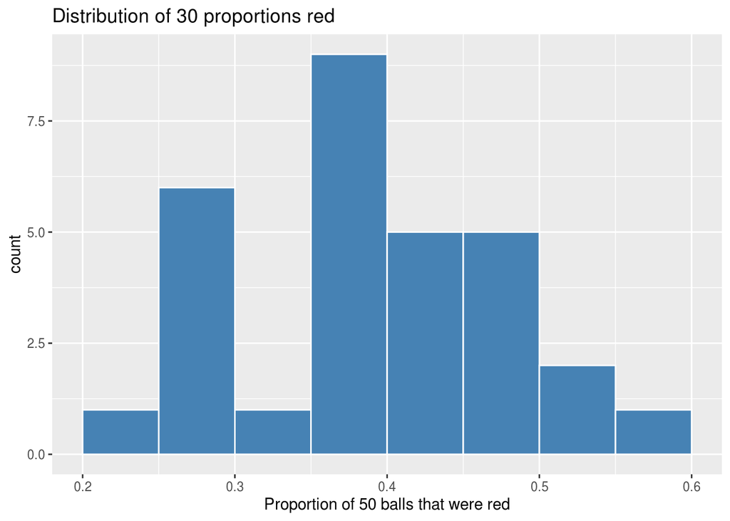

```r
ggplot(virtual_prop_red, aes(x = prop_red)) +
  geom_histogram(binwidth = 0.05, boundary = 0.4, color = "white", fill = "steelblue") +
  labs(x = "Proportion of 50 balls that were red",
       title = "Distribution of 30 proportions red")
```

### 1.2.1 Exercise

Redo the above activity with 1000 repeated samples and state your conclusions.

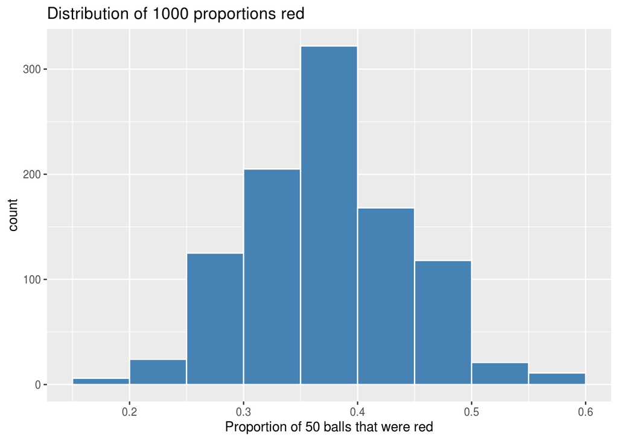

```r
virtual_samples <- bowl %>%
  rep_sample_n(size = 50, reps = 1000)

virtual_prop_red <- virtual_samples %>%
  group_by(replicate) %>%
  summarize(red = sum(color == "red")) %>%
  mutate(prop_red = red / 50)

ggplot(virtual_prop_red, aes(x = prop_red)) +
  geom_histogram(binwidth = 0.05, boundary = 0.4, color = "white", fill = "steelblue") +
  labs(x = "Proportion of 50 balls that were red",
       title = "Distribution of 1000 proportions red")
```

### 1.2.2 Using different shovels

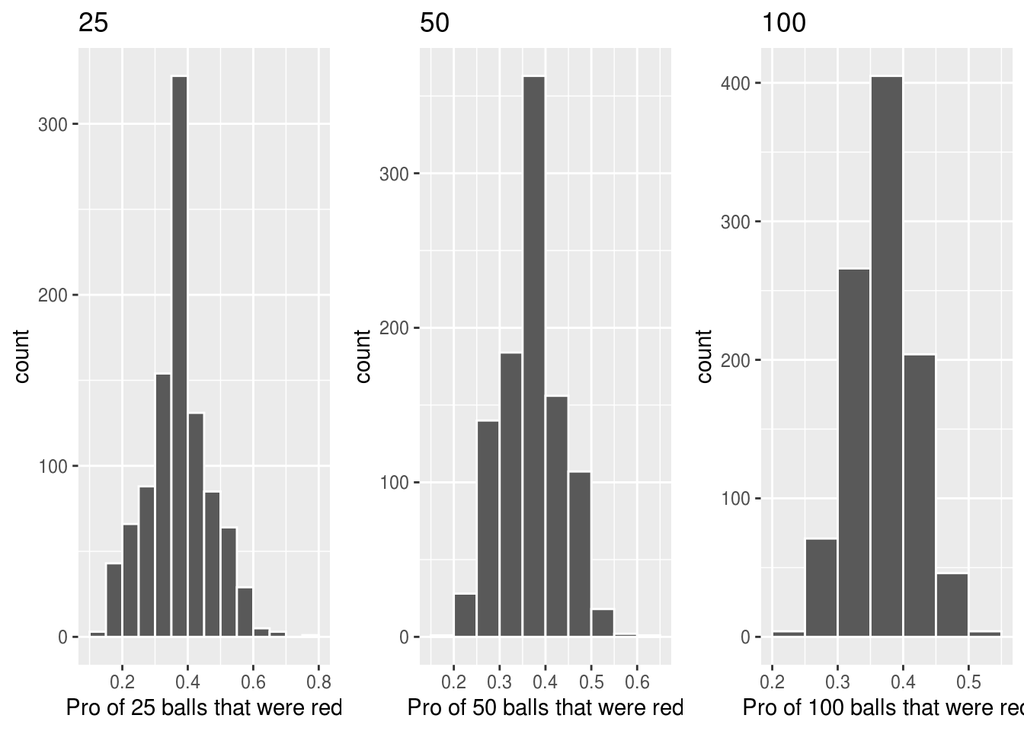

```r
# Segment 1: sample size = 25 ------------------------------
# 1.a) Virtually use shovel 1000 times
virtual_samples_25 <- bowl %>%
  rep_sample_n(size = 25, reps = 1000)

# 1.b) Compute resulting 1000 replicates of proportion red
virtual_prop_red_25 <- virtual_samples_25 %>%
  group_by(replicate) %>%
  summarize(red = sum(color == "red")) %>%
  mutate(prop_red = red / 25)

# 1.c) Plot distribution via a histogram
p1 <- ggplot(virtual_prop_red_25, aes(x = prop_red)) +
  geom_histogram(binwidth = 0.05, boundary = 0.4, color = "white") +
  labs(x = "Pro of 25 balls that were red", title = "25")

# Segment 2: sample size = 50 ------------------------------
# 2.a) Virtually use shovel 1000 times
virtual_samples_50 <- bowl %>%
  rep_sample_n(size = 50, reps = 1000)

# 2.b) Compute resulting 1000 replicates of proportion red
virtual_prop_red_50 <- virtual_samples_50 %>%
  group_by(replicate) %>%
  summarize(red = sum(color == "red")) %>%
  mutate(prop_red = red / 50)

# 2.c) Plot distribution via a histogram
p2 <- ggplot(virtual_prop_red_50, aes(x = prop_red)) +
  geom_histogram(binwidth = 0.05, boundary = 0.4, color = "white") +
  labs(x = "Pro of 50 balls that were red", title = "50")

# Segment 3: sample size = 100 ------------------------------
# 3.a) Virtually using shovel with 100 slots 1000 times
virtual_samples_100 <- bowl %>%
  rep_sample_n(size = 100, reps = 1000)

# 3.b) Compute resulting 1000 replicates of proportion red
virtual_prop_red_100 <- virtual_samples_100 %>%
  group_by(replicate) %>%
  summarize(red = sum(color == "red")) %>%
  mutate(prop_red = red / 100)

# 3.c) Plot distribution via a histogram
p3 <- ggplot(virtual_prop_red_100, aes(x = prop_red)) +
  geom_histogram(binwidth = 0.05, boundary = 0.4, color = "white") +
  labs(x = "Pro of 100 balls that were red", title = "100")


plot_grid(p1, p2, p3, nrow = 1)
```

```r
# n = 25
virtual_prop_red_25 %>%
  summarize(sd = sd(prop_red))
```

```
## # A tibble: 1 x 1
##       sd
##    <dbl>
## 1 0.0953
```

```r
# n = 50
virtual_prop_red_50 %>%
  summarize(sd = sd(prop_red))
```

```
## # A tibble: 1 x 1
##       sd
##    <dbl>
## 1 0.0659
```

```r
# n = 100
virtual_prop_red_100 %>%
  summarize(sd = sd(prop_red))
```

```
## # A tibble: 1 x 1
##       sd
##    <dbl>
## 1 0.0477
```

As the sample size increases, our numerical measure of spread decreases; there is less variation in our proportions red. In other words, as the sample size increases, our guesses at the true proportion of the bowl’s balls that are red get more consistent and precise.

## 1.3 Summary

This was our first attempt at understanding two key concepts relating to sampling for estimation:

- The effect of sampling variation on our estimates.
- The effect of sample size on sampling variation.

## 1.4 Terminology/Notation

1. **(Study) Population**: A (study) population is a collection of individuals or observations about which we are interested. We mathematically denote the population’s size using upper case N. In our simulations the (study) population was the collection of N = 2400 identically sized red and white balls contained in the bowl.
2. **Population parameter**: A population parameter is a numerical summary quantity about the population that is unknown, but you wish you knew. For example, when this quantity is a mean, the population parameter of interest is the population mean which is denoted with $\mu$. In our simulations; however, since we were interested in the proportion of the bowl’s balls that were red, the population parameter is the population proportion which is denoted with the letter $p$.
3. **Census**: An exhaustive enumeration or counting of all $N$ individuals or observations in the population in order to compute the population parameter’s value exactly. In our simulations, this would correspond to manually going over all $N=2400$ balls in the bowl and counting the number that are red and computing the population proportion $p$ of the balls that are red exactly. When the number $N$ of individuals or observations in our population is large, as was the case with our bowl, a census can be very expensive in terms of time, energy, and money.
4. **Sampling**: Sampling is the act of collecting a sample from the population when we don’t have the means to perform a census. We mathematically denote the sample’s size using lower case $n$, as opposed to upper case $N$ which denotes the population’s size. Typically the sample size $n$ is much smaller than the population size $N$, thereby making sampling a much cheaper procedure than a census. In our simulations, we used shovels with $25, 50,$ and $100$ slots to extract a sample of size $n=25, n=50,$ and $n=100$ balls.
5. **Point estimate** *(AKA sample statistic)*: A summary statistic computed from the sample that estimates the unknown population parameter. In our simulations, recall that the unknown population parameter was the population proportion and that this is mathematically denoted with $p$. Our point estimate is the sample proportion: the proportion of the shovel’s balls that are red. In other words, it is our guess of the proportion of the bowl’s balls balls that are red. We mathematically denote the sample proportion using $\hat{p}$; the “hat” on top of the p indicates that it is an estimate of the unknown population proportion $p$.
6. **Representative sampling**: A sample is said be a representative sample if it is representative of the population. In other words, are the sample’s characteristics a good representation of the population’s characteristics? In our simulations, are the samples of $n$ balls extracted using our shovels representative of the bowl’s $N=2400$ balls?
7. **Generalizability**: We say a sample is generalizable if any results based on the sample can generalize to the population. In other words, can the value of the point estimate be generalized to estimate the value of the population parameter well? In our simulations, can we generalize the values of the sample proportions red of our shovels to the population proportion red of the bowl? Using mathematical notation, is $\hat{p}$ a “good guess” of $p$?
8. **Bias**: In a statistical sense, we say bias occurs if certain individuals or observations in a population have a higher chance of being included in a sample than others. We say a sampling procedure is unbiased if every observation in a population had an equal chance of being sampled. In our simulations, since each ball had the same size and hence an equal chance of being sample in our shovels, our samples were unbiased.
9. **Random sampling**: We say a sampling procedure is random if we sample randomly from the population in an unbiased fashion. In our simulations, this would correspond to sufficiently mixing the bowl before each use of the shovel.

Putting it all together…

- If we extract a sample of $n=50$ balls at random, in other words we mix the equally-sized balls before using the shovel, then…
- the contents of the shovel are an *unbiased representation* of the contents of the bowl’s 2400 balls, thus…
- any result based on the sample of balls can *generalize* to the bowl, thus…
- the sample proportion $\hat{p}$ of the $n=50$ balls in the shovel that are red is a “good guess” of the population proportion $p$ of the $N=2400$ balls that are red, thus…
- instead of manually going over all the balls in the bowl, we can *infer* about the bowl using the shovel.

> Definition 1.1: The sampling distribution of a Statistic (e.g. Mean, Median, Proportion, etc) is its probability distribution.

> Definition 1.2: The standard deviation of a sampling distribution is called the standard error.

## 1.5 Exercise

Find and plot the sampling distribution of the proportion ($\hat{p}$) of heads when you flip a fair coin. (Use 5000 sets of 10 tosses)

1. What is the sample size?
2. How many experiments?
3. Find and plot the sampling distribution of $\hat{p}$.
4. Find the average of $\hat{p}$.
5. Find the standard error of the sampling distribution of $\hat{p}$.
6. What happens to the standard error, when you increase the sample size?

```r
coin = c("Heads", "Tails")
coin = tbl_df(coin)
coin
```

```
## # A tibble: 2 x 1
##   value
##   <chr>
## 1 Heads
## 2 Tails
```

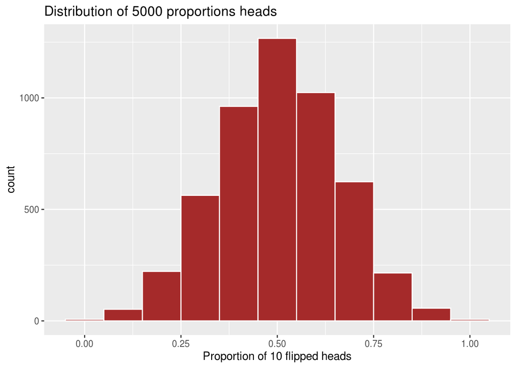

```r
vs = coin %>% rep_sample_n(size = 10, reps = 5000, replace = TRUE)

vp = vs %>%
  group_by(replicate) %>%
  summarize(Heads = sum(value == "Heads")) %>%
  mutate(pHeads = Heads / 10)

ggplot(vp, aes(x = pHeads)) +
  geom_histogram(binwidth = 0.1, color = "white", fill = "brown") +
  labs(x = "Proportion of 10 flipped heads",
       title = "Distribution of 5000 proportions heads")
```

```r
mean(vp$pHeads)
```

```
## [1] 0.50366
```

```r
sd(vp$pHeads)
```

```
## [1] 0.1597301
```

## 1.6 Brand Name Distributions

### 1.6.1 Normal Distribution

The normal distribution is defined by the following probability density function, where $\mu$ is the population mean and $\sigma$ is the standard deviation.

$f(x) = \dfrac{1}{\sigma \sqrt{2 \pi}}e^{-(x-\mu)^2/{2\sigma^2}}$

If a random variable $X$ follows the normal distribution, then we write: $X \sim N(\mu, \sigma^2)$

Here is how the normal density looks like: Ex: here $X \sim N(0, 1)$

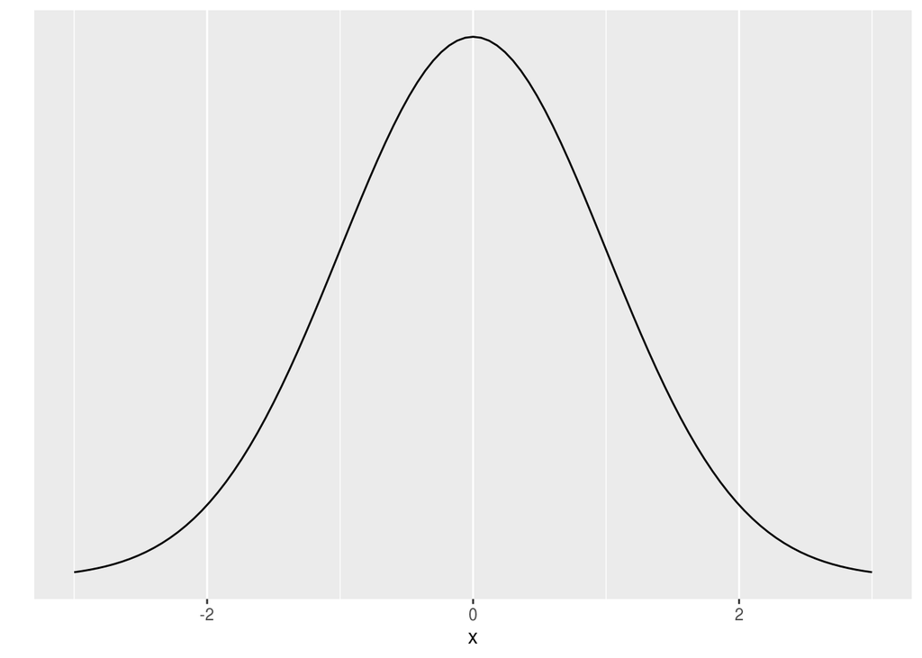